# Part I - Ford GoBike System Data Exploration

## Introduction

We will analyze a bike-sharing system covering the greater San Francisco Bay area. The data set includes informations about members and also the trip itself.

Attributes of the data set is given below:

- duration_sec
- start_time
- end_time
- start_station_id
- start_station_name
- start_station_latitude
- start_station_longitude
- end_station_id
- end_station_name
- end_station_latitude
- end_station_longitude
- bike_id user_type
- member_birth_year
- member_gender
- bike_share_for_all_trip

First we will start by importing and cleaning hour data and then we will make hour analyze and visualizations steps.

## Preliminary Wrangling

```python
# import all packages and set plots to be embedded inline
import numpy as np
import pandas as pd
import matplotlib.pyplot as plt
import seaborn as sb
import datetime as dt #will use this to do extraction on datetime attributes
%matplotlib inline
```

```python
# Load the dataset
trips = pd.read_csv("201902-fordgobike-tripdata.csv")
# Checking some values
print(trips.head(10))
```

```
   duration_sec                start_time                  end_time  \
0         52185  2019-02-28 17:32:10.1450  2019-03-01 08:01:55.9750
1         42521  2019-02-28 18:53:21.7890  2019-03-01 06:42:03.0560
2         61854  2019-02-28 12:13:13.2180  2019-03-01 05:24:08.1460
3         36490  2019-02-28 17:54:26.0100  2019-03-01 04:02:36.8420
4          1585  2019-02-28 23:54:18.5490  2019-03-01 00:20:44.0740
5          1793  2019-02-28 23:49:58.6320  2019-03-01 00:19:51.7600
6          1147  2019-02-28 23:55:35.1040  2019-03-01 00:14:42.5880
7          1615  2019-02-28 23:41:06.7660  2019-03-01 00:08:02.7560
8          1570  2019-02-28 23:41:48.7900  2019-03-01 00:07:59.7150
9          1049  2019-02-28 23:49:47.6990  2019-03-01 00:07:17.0250

   start_station_id                                start_station_name  \
0              21.0  Montgomery St BART Station (Market St at 2nd St)
1              23.0                     The Embarcadero at Steuart St
```

[output cut: 56 more lines]

```python
# checking null values
trips.isnull().sum()
```

```
duration_sec                  0
start_time                    0
end_time                      0
start_station_id            197
start_station_name          197
start_station_latitude        0
start_station_longitude       0
end_station_id              197
end_station_name            197
end_station_latitude          0
end_station_longitude         0
bike_id                       0
user_type                     0
member_birth_year          8265
member_gender              8265
bike_share_for_all_trip       0
dtype: int64
```

```python
#drop nulls
trips = trips.dropna()
trips.isnull().sum()
```

```
duration_sec               0
start_time                 0
end_time                   0
start_station_id           0
start_station_name         0
start_station_latitude     0
start_station_longitude    0
end_station_id             0
end_station_name           0
end_station_latitude       0
end_station_longitude      0
bike_id                    0
user_type                  0
member_birth_year          0
member_gender              0
bike_share_for_all_trip    0
dtype: int64
```

```python
#Check duplicated row
trips.duplicated().sum()
```

```
0
```

```python
#Adding durations in minutes
# Converting the seconds into minutes for better understanding of the graph.
trips['duration_min'] = trips['duration_sec'] / 60
```

```python
# change some datatypes considering datas use case
dtype= {'start_time': 'datetime64',
        'end_time': 'datetime64',
        'start_station_id': 'object',
        'end_station_id': 'object',
        'start_station_latitude': 'object',
        'start_station_longitude':  'object',
        'end_station_latitude':  'object',
        'end_station_longitude':  'object',
        'bike_id': 'object',
        'member_birth_year': 'object',
        'member_gender': 'category',
        'user_type': 'category',
        'duration_min': 'int64'}

trips = trips.astype(dtype)
```

```python
trips.info()
```

```
<class 'pandas.core.frame.DataFrame'>
Int64Index: 174952 entries, 0 to 183411
Data columns (total 17 columns):
duration_sec               174952 non-null int64
start_time                 174952 non-null datetime64[ns]
end_time                   174952 non-null datetime64[ns]
start_station_id           174952 non-null object
start_station_name         174952 non-null object
start_station_latitude     174952 non-null object
start_station_longitude    174952 non-null object
end_station_id             174952 non-null object
end_station_name           174952 non-null object
end_station_latitude       174952 non-null object
end_station_longitude      174952 non-null object
bike_id                    174952 non-null object
user_type                  174952 non-null category
member_birth_year          174952 non-null object
member_gender              174952 non-null category
bike_share_for_all_trip    174952 non-null object
duration_min               174952 non-null int64
dtypes: category(2), datetime64[ns](2), int64(2), object(11)
memory usage: 21.7+ MB
```

```python
trips.head(10)
```

|  | duration_sec | start_time | end_time | start_station_id | start_station_name | start_station_latitude | start_station_longitude | end_station_id | end_station_name | end_station_latitude | end_station_longitude | bike_id | user_type | member_birth_year | member_gender | bike_share_for_all_trip | duration_min |
| --- | --- | --- | --- | --- | --- | --- | --- | --- | --- | --- | --- | --- | --- | --- | --- | --- | --- |
| 0 | 52185 | 2019-02-28 17:32:10.145 | 2019-03-01 08:01:55.975 | 21 | Montgomery St BART Station (Market St at 2nd St) | 37.7896 | -122.401 | 13 | Commercial St at Montgomery St | 37.7942 | -122.403 | 4902 | Customer | 1984 | Male | No | 869 |
| 2 | 61854 | 2019-02-28 12:13:13.218 | 2019-03-01 05:24:08.146 | 86 | Market St at Dolores St | 37.7693 | -122.427 | 3 | Powell St BART Station (Market St at 4th St) | 37.7864 | -122.405 | 5905 | Customer | 1972 | Male | No | 1030 |
| 3 | 36490 | 2019-02-28 17:54:26.010 | 2019-03-01 04:02:36.842 | 375 | Grove St at Masonic Ave | 37.7748 | -122.447 | 70 | Central Ave at Fell St | 37.7733 | -122.444 | 6638 | Subscriber | 1989 | Other | No | 608 |
| 4 | 1585 | 2019-02-28 23:54:18.549 | 2019-03-01 00:20:44.074 | 7 | Frank H Ogawa Plaza | 37.8046 | -122.272 | 222 | 10th Ave at E 15th St | 37.7927 | -122.249 | 4898 | Subscriber | 1974 | Male | Yes | 26 |
| 5 | 1793 | 2019-02-28 23:49:58.632 | 2019-03-01 00:19:51.760 | 93 | 4th St at Mission Bay Blvd S | 37.7704 | -122.391 | 323 | Broadway at Kearny | 37.798 | -122.406 | 5200 | Subscriber | 1959 | Male | No | 29 |
| 6 | 1147 | 2019-02-28 23:55:35.104 | 2019-03-01 00:14:42.588 | 300 | Palm St at Willow St | 37.3173 | -121.885 | 312 | San Jose Diridon Station | 37.3297 | -121.902 | 3803 | Subscriber | 1983 | Female | No | 19 |
| 7 | 1615 | 2019-02-28 23:41:06.766 | 2019-03-01 00:08:02.756 | 10 | Washington St at Kearny St | 37.7954 | -122.405 | 127 | Valencia St at 21st St | 37.7567 | -122.421 | 6329 | Subscriber | 1989 | Male | No | 26 |
| 8 | 1570 | 2019-02-28 23:41:48.790 | 2019-03-01 00:07:59.715 | 10 | Washington St at Kearny St | 37.7954 | -122.405 | 127 | Valencia St at 21st St | 37.7567 | -122.421 | 6548 | Subscriber | 1988 | Other | No | 26 |
| 9 | 1049 | 2019-02-28 23:49:47.699 | 2019-03-01 00:07:17.025 | 19 | Post St at Kearny St | 37.789 | -122.403 | 121 | Mission Playground | 37.7592 | -122.421 | 6488 | Subscriber | 1992 | Male | No | 17 |
| 10 | 458 | 2019-02-28 23:57:57.211 | 2019-03-01 00:05:35.435 | 370 | Jones St at Post St | 37.7873 | -122.413 | 43 | San Francisco Public Library (Grove St at Hyde... | 37.7788 | -122.416 | 5318 | Subscriber | 1996 | Female | Yes | 7 |

```python
print(trips.shape)
print(trips.dtypes)
```

```
(174952, 17)
duration_sec                        int64
start_time                 datetime64[ns]
end_time                   datetime64[ns]
start_station_id                   object
start_station_name                 object
start_station_latitude             object
start_station_longitude            object
end_station_id                     object
end_station_name                   object
end_station_latitude               object
end_station_longitude              object
bike_id                            object
user_type                        category
member_birth_year                  object
member_gender                    category
bike_share_for_all_trip            object
duration_min                        int64
dtype: object
```

### What is the structure of your dataset?

> There are 174952 trips and 16 attributes on my current dataset. Most variables are information about the trip itself and some of them includes values about the member.

### What is/are the main feature(s) of interest in your dataset?

> I am mostly interested in to see what effects the trip times the most. Also I will make some additional observations about member preferences and locations effect on trips and its durations.

### What features in the dataset do you think will help support your investigation into your feature(s) of interest?

> I think start and end point informations can be quite useful to determine poplar locations. Also member category can help me the understand if subscriptions system has an effect.

## Univariate Exploration

#### What is the avarage duration time?

- First I will start by taking a look at the duration times to see an avarage duration for trips.

```
Text(0,0.5,'Frequency')
```

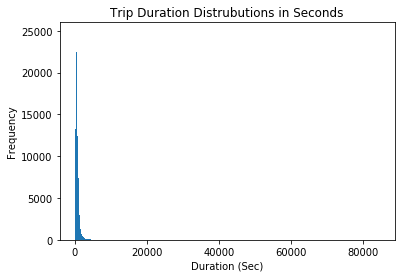

```python
binedges = np.arange(0, trips['duration_sec'].max() + 100 , 100)#set up bins
#plot
plt.hist(data = trips , x = 'duration_sec' , bins = binedges)
plt.title('Trip Duration Distrubutions in Seconds')
plt.xlabel('Duration (Sec)')
plt.ylabel('Frequency')
```

There is a long tailed distrubution in our data.

- #### I also wanted to take a look at duration in minutes

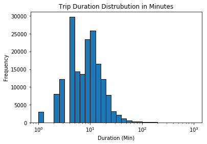

```python
binedges = 10**np.arange(0 , 3+0.1 , 0.1)
plt.xticks([10,20,30,40,50,60]);
plt.hist(data = trips , x = 'duration_min' , bins = binedges, edgecolor = 'black');
plt.title('Trip Duration Distrubution in Minutes')
plt.xlabel('Duration (Min)');
plt.ylabel('Frequency')
plt.xscale('log');
```

```python
trips = trips[trips['duration_sec'] < 3600]
```

```
 <a list of 9 Text xticklabel objects>)
```

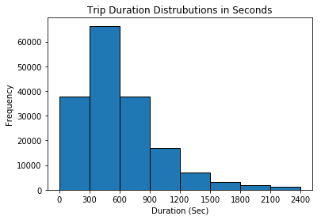

```python
binedges = np.arange(0, trips['duration_sec'].quantile(0.99) + 300 , 300).astype(int)#set up bins
#plot
plt.hist(data = trips , x = 'duration_sec' , bins = binedges,edgecolor = 'black')
plt.title('Trip Duration Distrubutions in Seconds')
plt.xlabel('Duration (Sec)')
plt.ylabel('Frequency')
plt.xticks(binedges,binedges)
```

```python
trips.info()
```

```
<class 'pandas.core.frame.DataFrame'>
Int64Index: 173566 entries, 4 to 183411
Data columns (total 17 columns):
duration_sec               173566 non-null int64
start_time                 173566 non-null datetime64[ns]
end_time                   173566 non-null datetime64[ns]
start_station_id           173566 non-null object
start_station_name         173566 non-null object
start_station_latitude     173566 non-null object
start_station_longitude    173566 non-null object
end_station_id             173566 non-null object
end_station_name           173566 non-null object
end_station_latitude       173566 non-null object
end_station_longitude      173566 non-null object
bike_id                    173566 non-null object
user_type                  173566 non-null category
member_birth_year          173566 non-null object
member_gender              173566 non-null category
bike_share_for_all_trip    173566 non-null object
duration_min               173566 non-null int64
dtypes: category(2), datetime64[ns](2), int64(2), object(11)
memory usage: 21.5+ MB
```

#### What are the member types percentage?

- I will examine the member types.

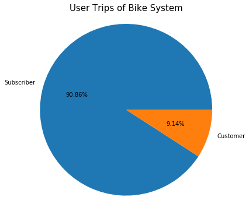

```python
#User type by it's percentage on pie chart

plt.figure(figsize=(10,6))
utype_value_count = trips['user_type'].value_counts()
plt.pie(utype_value_count, labels = utype_value_count.index, autopct='%1.2f%%');
plt.axis('square')
plt.title('User Trips of Bike System', fontsize=15);
```

Nearly 90% of the members are subscribers of the system.

#### What is the distrubution of trips within a day?

- To examine that I will see the distrubutions of start time.

```python
#adding start_hour column
trips['start_hour'] = pd.DatetimeIndex(trips['start_time']).hour
trips.head()
```

|  | duration_sec | start_time | end_time | start_station_id | start_station_name | start_station_latitude | start_station_longitude | end_station_id | end_station_name | end_station_latitude | end_station_longitude | bike_id | user_type | member_birth_year | member_gender | bike_share_for_all_trip | duration_min | start_hour |
| --- | --- | --- | --- | --- | --- | --- | --- | --- | --- | --- | --- | --- | --- | --- | --- | --- | --- | --- |
| 4 | 1585 | 2019-02-28 23:54:18.549 | 2019-03-01 00:20:44.074 | 7 | Frank H Ogawa Plaza | 37.8046 | -122.272 | 222 | 10th Ave at E 15th St | 37.7927 | -122.249 | 4898 | Subscriber | 1974 | Male | Yes | 26 | 23 |
| 5 | 1793 | 2019-02-28 23:49:58.632 | 2019-03-01 00:19:51.760 | 93 | 4th St at Mission Bay Blvd S | 37.7704 | -122.391 | 323 | Broadway at Kearny | 37.798 | -122.406 | 5200 | Subscriber | 1959 | Male | No | 29 | 23 |
| 6 | 1147 | 2019-02-28 23:55:35.104 | 2019-03-01 00:14:42.588 | 300 | Palm St at Willow St | 37.3173 | -121.885 | 312 | San Jose Diridon Station | 37.3297 | -121.902 | 3803 | Subscriber | 1983 | Female | No | 19 | 23 |
| 7 | 1615 | 2019-02-28 23:41:06.766 | 2019-03-01 00:08:02.756 | 10 | Washington St at Kearny St | 37.7954 | -122.405 | 127 | Valencia St at 21st St | 37.7567 | -122.421 | 6329 | Subscriber | 1989 | Male | No | 26 | 23 |
| 8 | 1570 | 2019-02-28 23:41:48.790 | 2019-03-01 00:07:59.715 | 10 | Washington St at Kearny St | 37.7954 | -122.405 | 127 | Valencia St at 21st St | 37.7567 | -122.421 | 6548 | Subscriber | 1988 | Other | No | 26 | 23 |

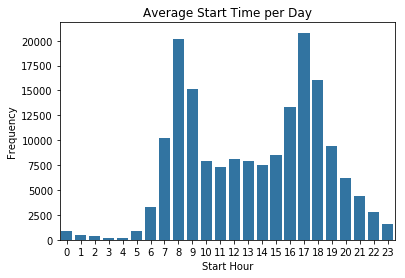

```python
sb.countplot(data=trips,x='start_hour', color=sb.color_palette()[0])
plt.title('Average Start Time per Day')
plt.xlabel('Start Hour')
plt.ylabel('Frequency');
```

Bike trips rates are higher during the day. Especially on rush hours. People might be prefering the bike rides to go to work or school so counts might be higher.

#### What are the distrubutions according to date?

- We will extract the day of start_time.

```python
#Add days in data according to start_time.
trips['start_day'] = trips['start_time'].dt.day_name()
trips.head()
```

|  | duration_sec | start_time | end_time | start_station_id | start_station_name | start_station_latitude | start_station_longitude | end_station_id | end_station_name | end_station_latitude | end_station_longitude | bike_id | user_type | member_birth_year | member_gender | bike_share_for_all_trip | duration_min | start_hour | start_day |
| --- | --- | --- | --- | --- | --- | --- | --- | --- | --- | --- | --- | --- | --- | --- | --- | --- | --- | --- | --- |
| 4 | 1585 | 2019-02-28 23:54:18.549 | 2019-03-01 00:20:44.074 | 7 | Frank H Ogawa Plaza | 37.8046 | -122.272 | 222 | 10th Ave at E 15th St | 37.7927 | -122.249 | 4898 | Subscriber | 1974 | Male | Yes | 26 | 23 | Thursday |
| 5 | 1793 | 2019-02-28 23:49:58.632 | 2019-03-01 00:19:51.760 | 93 | 4th St at Mission Bay Blvd S | 37.7704 | -122.391 | 323 | Broadway at Kearny | 37.798 | -122.406 | 5200 | Subscriber | 1959 | Male | No | 29 | 23 | Thursday |
| 6 | 1147 | 2019-02-28 23:55:35.104 | 2019-03-01 00:14:42.588 | 300 | Palm St at Willow St | 37.3173 | -121.885 | 312 | San Jose Diridon Station | 37.3297 | -121.902 | 3803 | Subscriber | 1983 | Female | No | 19 | 23 | Thursday |
| 7 | 1615 | 2019-02-28 23:41:06.766 | 2019-03-01 00:08:02.756 | 10 | Washington St at Kearny St | 37.7954 | -122.405 | 127 | Valencia St at 21st St | 37.7567 | -122.421 | 6329 | Subscriber | 1989 | Male | No | 26 | 23 | Thursday |
| 8 | 1570 | 2019-02-28 23:41:48.790 | 2019-03-01 00:07:59.715 | 10 | Washington St at Kearny St | 37.7954 | -122.405 | 127 | Valencia St at 21st St | 37.7567 | -122.421 | 6548 | Subscriber | 1988 | Other | No | 26 | 23 | Thursday |

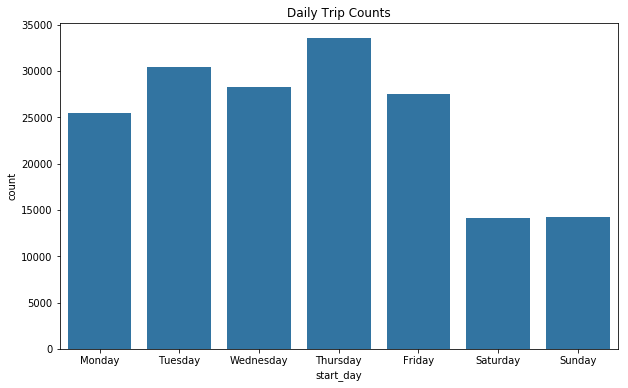

```python
days = ["Monday","Tuesday","Wednesday","Thursday","Friday","Saturday","Sunday"]
plt.figure(figsize=(10,6))
plt.title('Daily Trip Counts')
plt.xlabel('Start Day')
plt.ylabel('Frequency')
sb.countplot(data=trips, x='start_day', order = days ,color =sb.color_palette()[0]);
```

Members mostly use the system on weekdays. Which can confirm our previous theory that members might be using the system to get to work or school.

#### What are the most popular popular locations of stations?

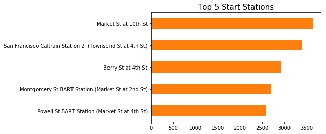

```python
plt.title('Top 5 Start Stations', fontsize=15)
trips.start_station_name.value_counts(ascending=True).tail(5).plot.barh(color =sb.color_palette()[1]);
```

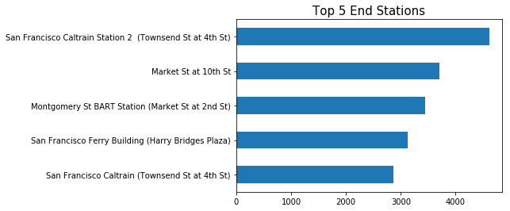

```python
plt.title('Top 5 End Stations', fontsize=15)
trips.end_station_name.value_counts(ascending=True).tail(5).plot.barh(color = sb.color_palette()[0]);
```

Market St at 10th St, San Francisco Caltrain Station 2 and Mongomery St BART Station are all in common on top 5 start and end stations. Which means they are the busiest among all stations.

#### What are the least popular locations of stations?

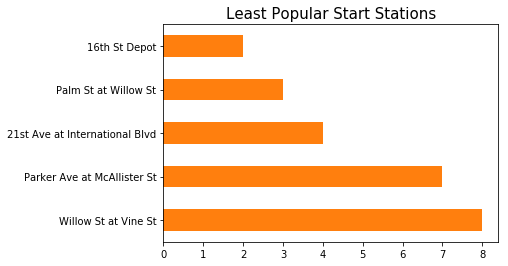

```python
plt.title('Least Popular Start Stations', fontsize=15)
trips.start_station_name.value_counts(ascending=False).tail(5).plot.barh(color =sb.color_palette()[1]);
```

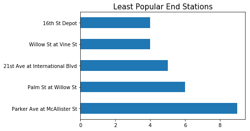

```python
plt.title('Least Popular End Stations', fontsize=15)
trips.end_station_name.value_counts(ascending=False).tail(5).plot.barh(color =sb.color_palette()[0]);
```

```python
trips.end_station_name.value_counts(ascending=False).tail(5)
```

```
Parker Ave at McAllister St       9
Palm St at Willow St              6
21st Ave at International Blvd    5
Willow St at Vine St              4
16th St Depot                     4
Name: end_station_name, dtype: int64
```

Parker Ave at McAllister St, Palm St at Willow St, 21st Ave International Blvd, 16th St Depot and Willow St at Vine St stations are all in common as the least popular end and start stations. We can assume they are the least busy stations

### Discuss the distribution(s) of your variable(s) of interest. Were there any unusual points? Did you need to perform any transformations?

> The distrubutions about the duration seemed mostly logical since majority of them were under 20 minutes. I only wanted to look at them in minutes too since seconds might be a little confusing.

### Of the features you investigated, were there any unusual distributions? Did you perform any operations on the data to tidy, adjust, or change the form of the data? If so, why did you do this?

> On the duration time, there were trips that takes more then 17 hours. Since avarage of durations within an hour, I eliminated the trips that takes more then that and also because those extreme values didn't look realistic.

## Bivariate Exploration

#### What is the relationship between duration of trips and the start hour?

```
Text(0.5,1,'Start Hour - Duration Relationship')
```

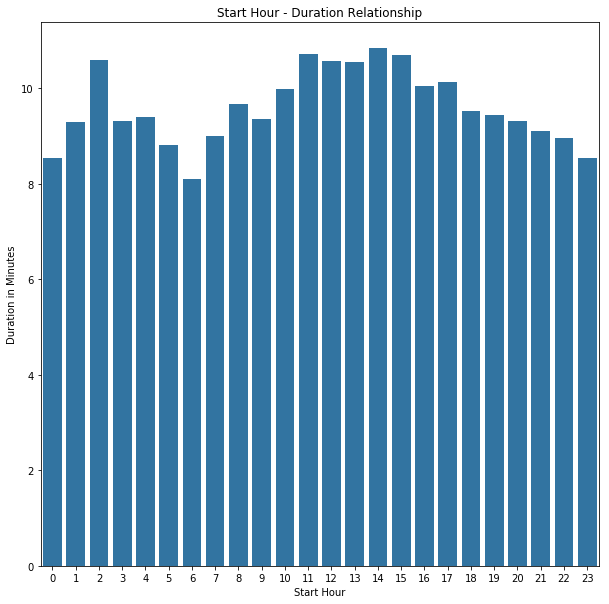

```python
#plot visual and format it
plt.figure(figsize = [10,10])
sb.barplot(data = trips , x = 'start_hour', y='duration_min',color =sb.color_palette()[0],ci=None)
plt.xlabel('Start Hour')
plt.ylabel('Duration in Minutes')
plt.title('Start Hour - Duration Relationship')
```

During day time, chance of longer trip taken are higher compared to the night time.

#### What is the relationship between members gender and trip duration?

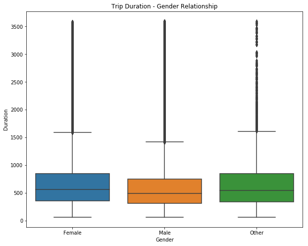

```python
plt.figure(figsize=(10,8))
sb.boxplot(data=trips, x='member_gender', y='duration_sec')
plt.title('Trip Duration - Gender Relationship')
plt.xlabel('Gender')
plt.ylabel('Duration');
```

While all the durations an distrubution of them are similar, we can see that avarege durations for female and others are higher then males. I will look in detail to see which is the highest.

```python
trips[trips['member_gender']=='Female'].duration_sec.mean()
```

```
675.4299215715381
```

```python
trips[trips['member_gender']=='Other'].duration_sec.mean()
```

```
685.89364679541006
```

Other gender types has higher durations.

#### What is the relationship between customer types and days?

```
Text(0.5,0,'Days')
```

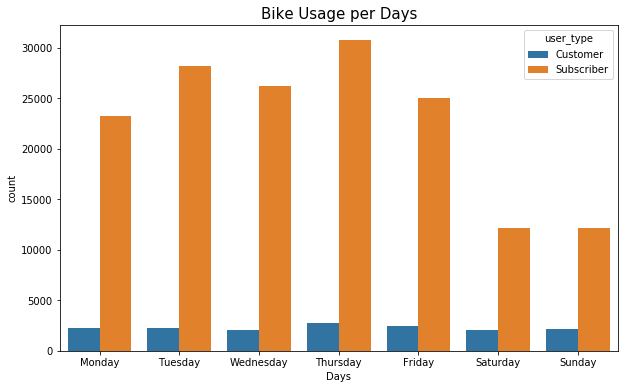

```python
plt.figure(figsize=(10,6))
plt.title('Bike Usage per Days', fontsize=15)
sb.countplot(data=trips, x='start_day', order=days, hue='user_type')
plt.xlabel('Days')
```

There isn't a huge change among customers between the days. But Subscribers are more likely to use bike system during weekdays, specially on tuesdays and thursdays

#### What are the relationships between genders and user types?

```
Text(0.5,0,'User Type')
```

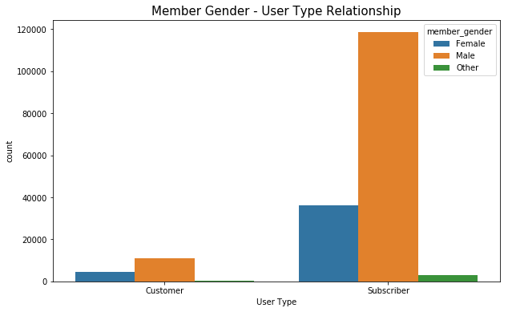

```python
plt.figure(figsize=(10,6))
plt.title('Member Gender - User Type Relationship', fontsize=15)
sb.countplot(data=trips, x='user_type', hue='member_gender')
plt.xlabel('User Type')
```

While most of the members are males in both categories, difference between males and females are much bigger on subscribers, compared to customers.

### Talk about some of the relationships you observed in this part of the investigation. How did the feature(s) of interest vary with other features in the dataset?

> The most obvious feature was start time's effect on trip durations. During day time, longer trips are taken compared to night time.

### Did you observe any interesting relationships between the other features (not the main feature(s) of interest)?

> Male Subscribers uses the system the most. Also customer type user trips count doesn't really matter on weekdays or weekends. But the subscribers trip count on weekends are almost the half of weekdays.

## Multivariate Exploration

```python
#First I will define a function for my repetitive barplot visualizations.
def multiBarPlot(df,xVar, yVar, hueVar, order=None, ci=None):
    #set plot dimensions
    plt.figure(figsize=[10,6])

    #plot using sb.barplot
    sb.barplot(data=trips,x=xVar, y=yVar, hue = hueVar, order=order, ci=ci)

    #clean up the variables name, replace _ with a space
    xVar = xVar.replace("_"," ")
    yVar = yVar.replace("_"," ")
```

#### What is the relationship between duration, user types and start hours?

```
Text(0.5,1,"User Type's Durations per Hour")
```

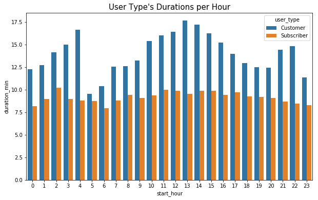

```python
multiBarPlot(trips,'start_hour', 'duration_min', 'user_type') #using my function to draw the plot
plt.title("User Type's Durations per Hour", fontsize=15)#giving it a title
```

On avarage, during the day customers have more trip durations then subscribers on all hours of the day. Subscribers durations doesn't change much during the day, it is mostly between 7.5 and 10 mins. Customers durations varies between 17.5 and 7.5 minutes. It has it peak around 13.00. So we can say longer trips are taken around noon by customers.

#### What is the relationship between duration, user types and days?

```
Text(0.5,1,"User Type's Durations per Day")
```

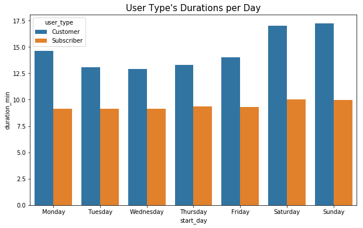

```python
multiBarPlot(trips,'start_day', 'duration_min', 'user_type',days)
plt.title("User Type's Durations per Day", fontsize=15)
```

Again, customers have more trip durations. And They tend to tkae longer trips on weekends.

#### What is the relationship between duration, genders and days?

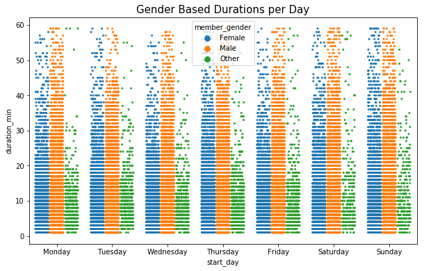

```python
plt.figure(figsize=(10,6))
plt.title("Gender Based Durations per Day", fontsize=15)
sb.stripplot(data=trips, x='start_day', y='duration_min', order = days, hue='member_gender',size= 3, jitter=0.35, dodge=True)
```

### Talk about some of the relationships you observed in this part of the investigation. Were there features that strengthened each other in terms of looking at your feature(s) of interest?

> Customers trip durations are longer in both terms of hours and days compared to the subscribers.

## Conclusions

> In conclusion we investigated that even tough more trips are taken during weekdays, trips tken on weekends are longer. Numbers are higher on rush hours which might mean that people are using the system to get to work or school.

> Also as side observations, subscribers has much more trips then customers but customers trips takes longer in general.